# Problem 5.14

From Class

October 27, 2021 at 10:04:01 AM

This document uses `tidyverse` by Wickham (2021), `infer` by Bray et al. (2021), `resampledata` by Chihara, Hesterberg, and Kim (2019), `gridExtra` by Auguie (2017), and `bookdown` by Xie (2021).

**Directions:**

1. Add comments to the code to make sure you understand what all steps are doing.
2. Add descriptive titles and labels to the base `R` histograms.
3. Discuss the difference between the permutation distribution and the bootstrap distribution. Make sure to discuss where each distribution is centered.

This document roughly follows problem 5.14 from page 145 of your text (Hesterberg and Chihara 2018). One important difference is that we are performing a two-sided test, not a directional test, as the book requests.

$$H_O: \mu_M - \mu_F = 0$$
$$H_A: \mu_M - \mu_F \neq 0$$

```r
head(Beerwings)
```

```
  ID Hotwings Beer Gender
1  1        4   24      F
2  2        5    0      F
3  3        5   12      F
4  4        6   12      F
5  5        7   12      F
6  6        7   12      F
```

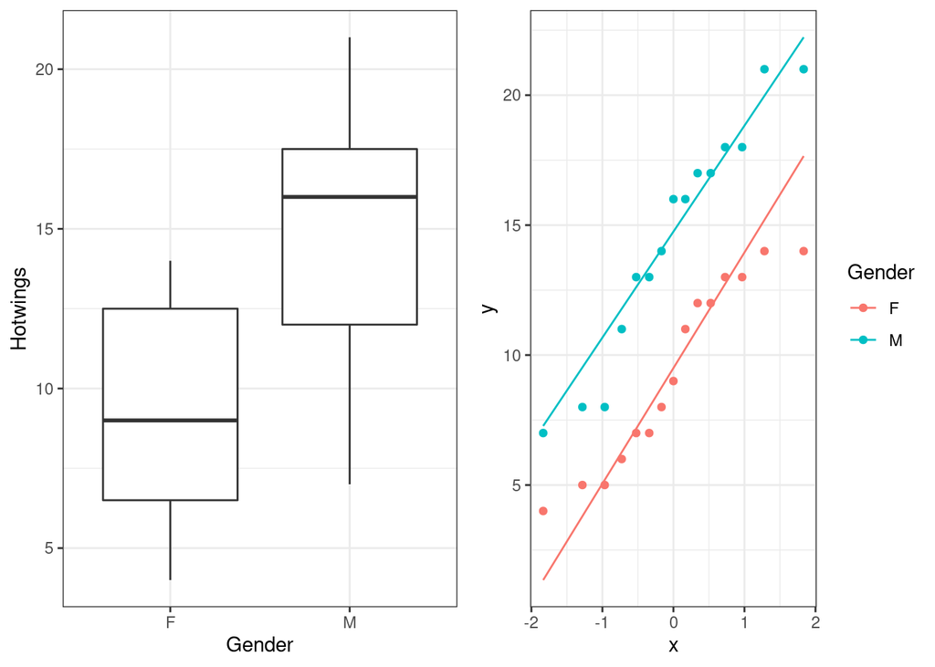

```r
ggplot(data = Beerwings, aes(x = Gender, y = Hotwings)) +
  geom_boxplot() +
  theme_bw() -> p1
ggplot(data = Beerwings, aes(sample = Hotwings, color = Gender)) +
  stat_qq() +
  stat_qq_line() +
  theme_bw() -> p2
grid.arrange(p1, p2, nrow = 1)
```

```r
Beerwings %>%
  group_by(Gender) %>%
  summarize(Means = mean(Hotwings), SD = sd(Hotwings), n = n())
```

```
# A tibble: 2 × 4
  Gender Means    SD     n
  <fct>  <dbl> <dbl> <int>
1 F       9.33  3.56    15
2 M      14.5   4.50    15
```

```r
Beerwings %>%
  group_by(Gender) %>%
  summarize(Means = mean(Hotwings)) %>%
  select(Means) %>%
  pull() %>%
  diff() -> obs_diff
obs_diff
```

```
[1] 5.2
```

```r
BWM <- Beerwings$Hotwings[Beerwings$Gender == "M"]
BWF <- Beerwings$Hotwings[Beerwings$Gender == "F"]
obs_diff <- mean(BWM) - mean(BWF)
obs_diff
```

```
[1] 5.2
```

```r
Beerwings %>%
  filter(Gender == "M") %>%
  select(Hotwings) %>%
  pull() -> BWM
BWM
```

```
 [1]  7  8  8 11 13 13 14 16 16 17 17 18 18 21 21
```

```r
Beerwings %>%
  filter(Gender == "F") %>%
  select(Hotwings) %>%
  pull() -> BWF
BWF
```

```
 [1]  4  5  5  6  7  7  8  9 11 12 12 13 13 14 14
```

```r
obs_diff <- mean(BWM) - mean(BWF)
obs_diff
```

```
[1] 5.2
```

```r
tapply(Beerwings$Hotwings, Beerwings$Gender, mean)
```

```
        F         M
 9.333333 14.533333
```

```r
diff(tapply(Beerwings$Hotwings, Beerwings$Gender, mean)) -> obs_diff
obs_diff
```

```
  M
5.2
```

```r
HWM <- subset(Beerwings, select = Hotwings, subset = Gender == "M", drop = TRUE)
HWF <- subset(Beerwings, select = Hotwings, subset = Gender == "F", drop = TRUE)
HWM
```

```
 [1]  7  8  8 11 13 13 14 16 16 17 17 18 18 21 21
```

```r
HWF
```

```
 [1]  4  5  5  6  7  7  8  9 11 12 12 13 13 14 14
```

```r
c(mean(HWF), mean(HWM))
```

```
[1]  9.333333 14.533333
```

```r
diff(c(mean(HWF), mean(HWM))) -> obs_diff
obs_diff
```

```
[1] 5.2
```

# 1 Generating the permutation distribution

## 1.1 Using `infer`

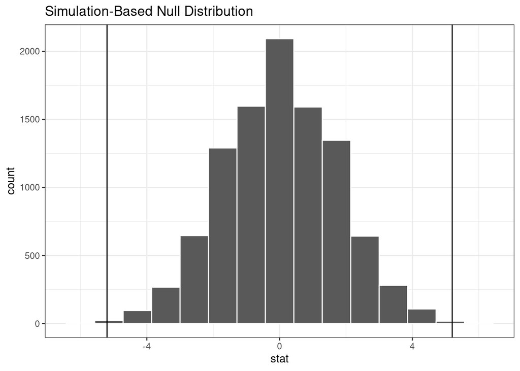

```r
Beerwings %>%
  specify(Hotwings ~ Gender) %>%
  hypothesize(null = "independence") %>%
  generate(reps = 10000, type = "permute") %>%
  calculate(stat = "diff in means", order = c("M", "F")) -> permDist
permDist %>%
  visualize() +
  theme_bw() +
  geom_vline(xintercept = c(-obs_diff, obs_diff))
```

```r
pvalue <- mean(permDist$stat >= obs_diff)*2
pvalue
```

```
[1] 0.0014
```

```r
#
get_p_value(permDist, obs_stat = obs_diff, direction = "two-sided")
```

```
# A tibble: 1 × 1
  p_value
    <dbl>
1  0.0014
```

## 1.2 Using `for()`

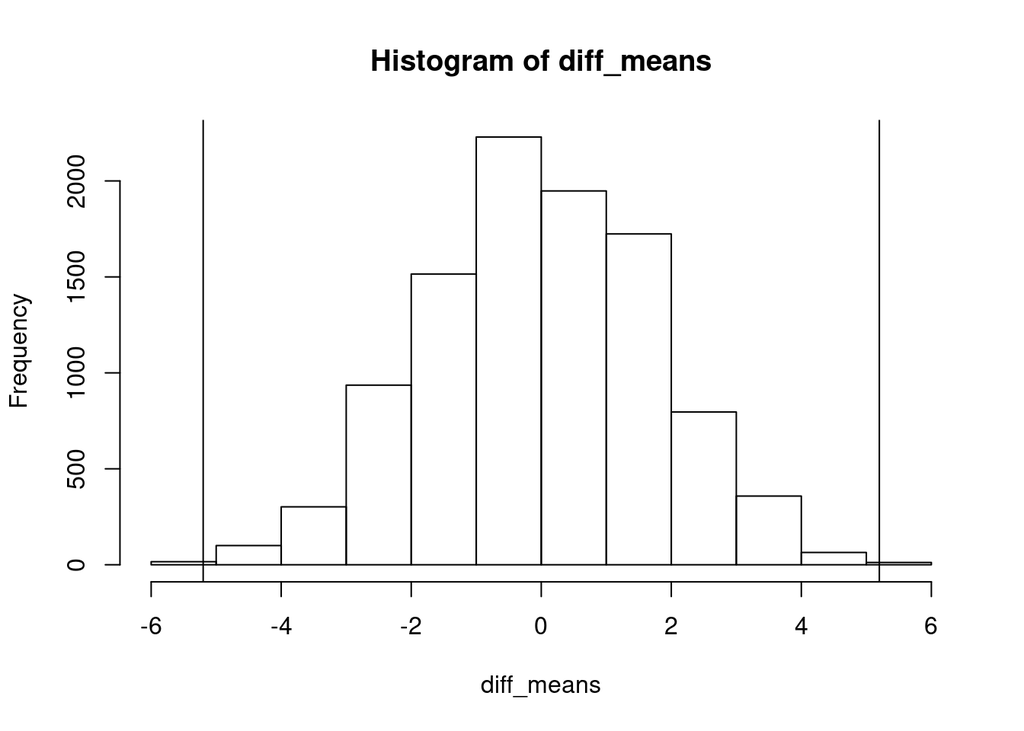

```r
B <- 10000
diff_means <- numeric(B)
for(i in 1:B){
  diff_means[i] <- diff(tapply(Beerwings$Hotwings, sample(Beerwings$Gender), mean))
}
hist(diff_means)
abline(v = c(-obs_diff, obs_diff))
```

```r
pvalue <- mean(diff_means >= obs_diff)*2
pvalue
```

```
[1] 0.0016
```

Based on a *p-value* of 0.0016 which is less than $\alpha = 0.05$ we reject the null hypothesis and conclude that there is evidence to suggest the average wings consumed by males is not the same as the average number of wings consumed by females.

# 2 Constructing 95% Bootstrap Percentile CI

## 2.1 Using `infer`

```r
Beerwings %>%
  specify(Hotwings ~ Gender) %>%
  generate(reps = 10000, type = "bootstrap") %>%
  calculate(stat = "diff in means", order = c("M", "F")) -> bootdist
bootdist %>%
get_confidence_interval(level = 0.95, type = "percentile") -> PCI
PCI
```

```
# A tibble: 1 × 2
  lower_ci upper_ci
     <dbl>    <dbl>
1     2.22     8.02
```

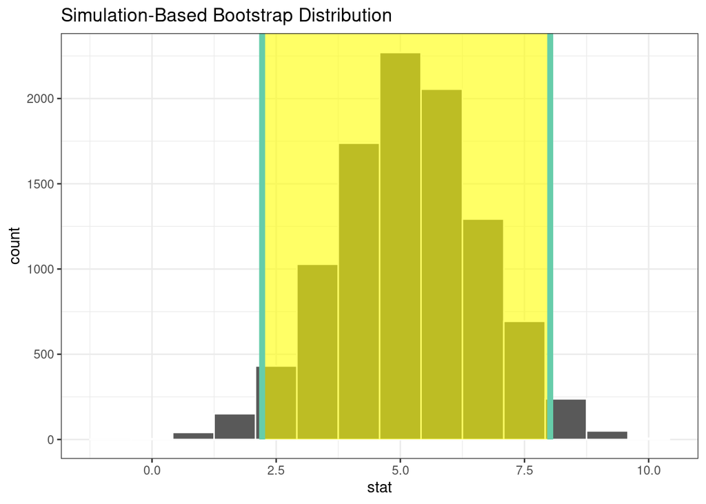

```r
visualize(bootdist) +
  shade_confidence_interval(endpoints = PCI, fill = "yellow") +
  theme_bw()
```

We are 95% confident that the true difference between the mean hotwings consumed by males and the mean hotwings consumed by females fall in the interval $(2.2 \text{ hotwings}, 8 \text{ hotwings})$.

## 2.2 Using a `for()` loop

```r
B <- 10000
diff_means <- numeric(B)
for(i in 1:B){
  bssM <- sample(HWM, size = 15, replace = TRUE)
  bssF <- sample(HWF, size = 15, replace = TRUE)
  diff_means[i] <- mean(bssM) - mean(bssF)
}
quantile(diff_means, probs = c(0.025, 0.975)) -> PCI2
PCI2
```

```
 2.5% 97.5%
  2.4   8.0
```

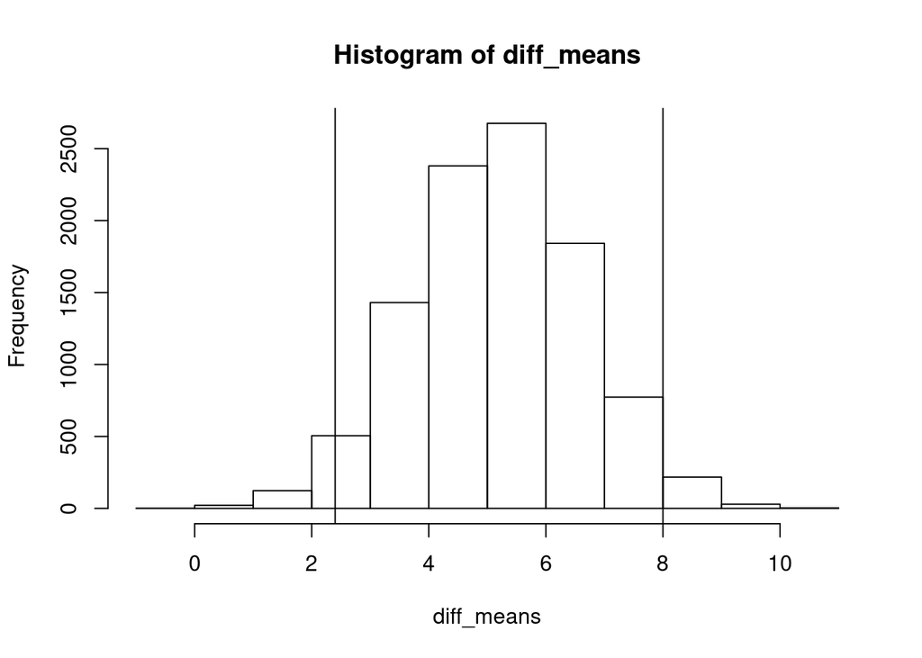

```r
hist(diff_means)
abline(v = PCI2)
```

We are 95% confident that the true difference between the mean hotwings consumed by males and the mean hotwings consumed by females fall in the interval $(2.4 \text{ hotwings}, 8 \text{ hotwings})$.

## References

Auguie, Baptiste. 2017. *gridExtra: Miscellaneous Functions for "Grid" Graphics*. https://CRAN.R-project.org/package=gridExtra.

Bray, Andrew, Chester Ismay, Evgeni Chasnovski, Simon Couch, Ben Baumer, and Mine Cetinkaya-Rundel. 2021. *Infer: Tidy Statistical Inference*. https://CRAN.R-project.org/package=infer.

Chihara, Laura, Tim Hesterberg, and Albert Y. Kim. 2019. *Resampledata: Data Sets for Mathematical Statistics with Resampling in r*. https://github.com/rudeboybert/resampledata.

Hesterberg, Tim C., and Laura M. Chihara. 2018. *Mathematical Statistics with Resampling and R*. 2nd edition. Hoboken, NJ: Wiley.

Wickham, Hadley. 2021. *Tidyverse: Easily Install and Load the Tidyverse*. https://CRAN.R-project.org/package=tidyverse.

Xie, Yihui. 2021. *Bookdown: Authoring Books and Technical Documents with r Markdown*. https://CRAN.R-project.org/package=bookdown.